# Data Exploration of Electric Vehicle Registrations in Washington State

Izzy Grabowski

2025-05-02

## Introduction

In this project, I explored data on electric vehicle (EV) adoption across Washington State to better understand where and why these vehicles are gaining popularity. As electric cars become increasingly important for reducing carbon emissions and combating climate change, I wanted to see patterns in registration data and consider the factors that might influence EV adoption. My analysis included key questions: Where and when are EVs most popular? Are they more common in rural or urban areas? What is the balance between fully electric vehicles (Battery Electric Vehicles or BEVs) and Plug-in Hybrid Electric Vehicles (PHEVs)? I also investigated how economic or policy conditions may play a role in EV trends, how average air quality (AQI) compares to EV counts in specific counties like Clallam and King, and which EV brands are the most popular across the state. This data exploration offers insight into the environmental, economic, and behavioral trends with EVs in Washington.

## Key Questions to Explore:

- 1. When and where are EVs most popular?
  - 1a) Which counties and cities in Washington have the highest number of registered EVs?
  - 1b) Are rural or urban areas more likely to adopt EVs?
- 2. What types of electric vehicles are being adopted?
  - 2a) What is the distribution of BEVs vs. PHEVs by county or city?
- 3. How do economic or policy factors relate to EV adoption?
- 4. How does average AQI in Clallam and King county compare to the number of EV registrations?
- 5. Which EV make is most popular in Washington?

# Cleaning EV dataset

```r
##CLEANING

library(readr)
Electric_Vehicle_Population_Data <- read_csv("~/Desktop/Electric_Vehicle_Population_Data.csv")
#View(Electric_Vehicle_Population_Data)

colnames(Electric_Vehicle_Population_Data)
```

```
##  [1] "VIN (1-10)"
##  [2] "County"
##  [3] "City"
##  [4] "State"
##  [5] "Postal Code"
##  [6] "Model Year"
##  [7] "Make"
##  [8] "Model"
##  [9] "Electric Vehicle Type"
## [10] "Clean Alternative Fuel Vehicle (CAFV) Eligibility"
## [11] "Electric Range"
## [12] "Base MSRP"
## [13] "Legislative District"
## [14] "DOL Vehicle ID"
## [15] "Vehicle Location"
## [16] "Electric Utility"
## [17] "2020 Census Tract"
```

```r
summary(Electric_Vehicle_Population_Data)
```

```
##   VIN (1-10)           County              City              State
##  Length:239747      Length:239747      Length:239747      Length:239747
##  Class :character   Class :character   Class :character   Class :character
##  Mode  :character   Mode  :character   Mode  :character   Mode  :character
##
##
##
##
##   Postal Code      Model Year       Make              Model
##  Min.   : 1731   Min.   :2000   Length:239747      Length:239747
##  1st Qu.:98052   1st Qu.:2020   Class :character   Class :character
##  Median :98126   Median :2023   Mode  :character   Mode  :character
##  Mean   :98177   Mean   :2021
##  3rd Qu.:98375   3rd Qu.:2024
##  Max.   :99577   Max.   :2026
##  NA's   :3
##  Electric Vehicle Type Clean Alternative Fuel Vehicle (CAFV) Eligibility
##  Length:239747         Length:239747
##  Class :character      Class :character
##  Mode  :character      Mode  :character
##
##
##
##
##  Electric Range     Base MSRP        Legislative District DOL Vehicle ID
##  Min.   :  0.00   Min.   :     0.0   Min.   : 1.00        Min.   :     4385
##  1st Qu.:  0.00   1st Qu.:     0.0   1st Qu.:17.00        1st Qu.:207129317
##  Median :  0.00   Median :     0.0   Median :32.00        Median :253359956
##  Mean   : 45.56   Mean   :   770.5   Mean   :28.88        Mean   :236318532
##  3rd Qu.: 38.00   3rd Qu.:     0.0   3rd Qu.:42.00        3rd Qu.:270175632
##  Max.   :337.00   Max.   :845000.0   Max.   :49.00        Max.   :479254772
##  NA's   :49       NA's   :49         NA's   :515
##  Vehicle Location   Electric Utility   2020 Census Tract
##  Length:239747      Length:239747      Length:239747
##  Class :character   Class :character   Class :character
##  Mode  :character   Mode  :character   Mode  :character
##
##
##
##
```

```r
ev_data <- Electric_Vehicle_Population_Data

str(ev_data)
```

```
## spc_tbl_ [239,747 × 17] (S3: spec_tbl_df/tbl_df/tbl/data.frame)
##  $ VIN (1-10)                                       : chr [1:239747] "1C4JJXP68P" "1G1FY6S03L" "KNDCE3LG9K" "1N4AZ0CP8E" ...
##  $ County                                           : chr [1:239747] "Yakima" "Kitsap" "King" "Thurston" ...
##  $ City                                             : chr [1:239747] "Yakima" "Kingston" "Seattle" "Olympia" ...
##  $ State                                            : chr [1:239747] "WA" "WA" "WA" "WA" ...
##  $ Postal Code                                      : num [1:239747] 98901 98346 98125 98506 98383 ...
##  $ Model Year                                       : num [1:239747] 2023 2020 2019 2014 2020 ...
##  $ Make                                             : chr [1:239747] "JEEP" "CHEVROLET" "KIA" "NISSAN" ...
##  $ Model                                            : chr [1:239747] "WRANGLER" "BOLT EV" "NIRO" "LEAF" ...
##  $ Electric Vehicle Type                            : chr [1:239747] "Plug-in Hybrid Electric Vehicle (PHEV)" "Battery Electric Vehicle (BEV)" "Battery Electric Vehicle (BEV)" "Battery Electric Vehicle (BEV)" ...
##  $ Clean Alternative Fuel Vehicle (CAFV) Eligibility: chr [1:239747] "Not eligible due to low battery range" "Clean Alternative Fuel Vehicle Eligible" "Clean Alternative Fuel Vehicle Eligible" "Clean Alternative Fuel Vehicle Eligible" ...
##  $ Electric Range                                   : num [1:239747] 21 259 239 84 293 238 0 208 93 291 ...
##  $ Base MSRP                                        : num [1:239747] 0 0 0 0 0 ...
##  $ Legislative District                             : num [1:239747] 15 23 46 22 23 23 22 35 22 34 ...
##  $ DOL Vehicle ID                                   : num [1:239747] 2.50e+08 1.41e+08 3.41e+06 1.82e+08 1.84e+06 ...
##  $ Vehicle Location                                 : chr [1:239747] "POINT (-120.50729 46.60464)" "POINT (-122.4977 47.79802)" "POINT (-122.30253 47.72656)" "POINT (-122.87741 47.05997)" ...
##  $ Electric Utility                                 : chr [1:239747] "PACIFICORP" "PUGET SOUND ENERGY INC" "CITY OF SEATTLE - (WA)|CITY OF TACOMA - (WA)" "PUGET SOUND ENERGY INC" ...
##  $ 2020 Census Tract                                : chr [1:239747] "53077001601" "53035940000" "53033000101" "53067012100" ...
##  - attr(*, "spec")=
##   .. cols(
##   ..   `VIN (1-10)` = col_character(),
##   ..   County = col_character(),
##   ..   City = col_character(),
##   ..   State = col_character(),
##   ..   `Postal Code` = col_double(),
##   ..   `Model Year` = col_double(),
##   ..   Make = col_character(),
##   ..   Model = col_character(),
##   ..   `Electric Vehicle Type` = col_character(),
##   ..   `Clean Alternative Fuel Vehicle (CAFV) Eligibility` = col_character(),
##   ..   `Electric Range` = col_double(),
##   ..   `Base MSRP` = col_double(),
##   ..   `Legislative District` = col_double(),
##   ..   `DOL Vehicle ID` = col_double(),
##   ..   `Vehicle Location` = col_character(),
##   ..   `Electric Utility` = col_character(),
##   ..   `2020 Census Tract` = col_character()
##   .. )
##  - attr(*, "problems")=<externalptr>
```

```r
summary(ev_data)
```

```
##   VIN (1-10)           County              City              State
##  Length:239747      Length:239747      Length:239747      Length:239747
##  Class :character   Class :character   Class :character   Class :character
##  Mode  :character   Mode  :character   Mode  :character   Mode  :character
##
##
##
##
##   Postal Code      Model Year       Make              Model
##  Min.   : 1731   Min.   :2000   Length:239747      Length:239747
##  1st Qu.:98052   1st Qu.:2020   Class :character   Class :character
##  Median :98126   Median :2023   Mode  :character   Mode  :character
##  Mean   :98177   Mean   :2021
##  3rd Qu.:98375   3rd Qu.:2024
##  Max.   :99577   Max.   :2026
##  NA's   :3
##  Electric Vehicle Type Clean Alternative Fuel Vehicle (CAFV) Eligibility
##  Length:239747         Length:239747
##  Class :character      Class :character
##  Mode  :character      Mode  :character
##
##
##
##
##  Electric Range     Base MSRP        Legislative District DOL Vehicle ID
##  Min.   :  0.00   Min.   :     0.0   Min.   : 1.00        Min.   :     4385
##  1st Qu.:  0.00   1st Qu.:     0.0   1st Qu.:17.00        1st Qu.:207129317
##  Median :  0.00   Median :     0.0   Median :32.00        Median :253359956
##  Mean   : 45.56   Mean   :   770.5   Mean   :28.88        Mean   :236318532
##  3rd Qu.: 38.00   3rd Qu.:     0.0   3rd Qu.:42.00        3rd Qu.:270175632
##  Max.   :337.00   Max.   :845000.0   Max.   :49.00        Max.   :479254772
##  NA's   :49       NA's   :49         NA's   :515
##  Vehicle Location   Electric Utility   2020 Census Tract
##  Length:239747      Length:239747      Length:239747
##  Class :character   Class :character   Class :character
##  Mode  :character   Mode  :character   Mode  :character
##
##
##
##
```

```r
head(ev_data)
```

```
## # A tibble: 6 × 17
##   `VIN (1-10)` County   City       State `Postal Code` `Model Year` Make   Model
##   <chr>        <chr>    <chr>      <chr>         <dbl>        <dbl> <chr>  <chr>
## 1 1C4JJXP68P   Yakima   Yakima     WA            98901         2023 JEEP   WRAN…
## 2 1G1FY6S03L   Kitsap   Kingston   WA            98346         2020 CHEVR… BOLT…
## 3 KNDCE3LG9K   King     Seattle    WA            98125         2019 KIA    NIRO
## 4 1N4AZ0CP8E   Thurston Olympia    WA            98506         2014 NISSAN LEAF
## 5 5YJXCAE29L   Kitsap   Silverdale WA            98383         2020 TESLA  MODE…
## 6 1G1FX6S02H   Kitsap   Kingston   WA            98346         2017 CHEVR… BOLT…
## # ℹ 9 more variables: `Electric Vehicle Type` <chr>,
## #   `Clean Alternative Fuel Vehicle (CAFV) Eligibility` <chr>,
## #   `Electric Range` <dbl>, `Base MSRP` <dbl>, `Legislative District` <dbl>,
## #   `DOL Vehicle ID` <dbl>, `Vehicle Location` <chr>, `Electric Utility` <chr>,
## #   `2020 Census Tract` <chr>
```

```r
ev_data <- na.omit(ev_data)
colSums(is.na(ev_data)) # remove rows with lots of missing data
```

```
##                                        VIN (1-10)
##                                                 0
##                                            County
##                                                 0
##                                              City
##                                                 0
##                                             State
##                                                 0
##                                       Postal Code
##                                                 0
##                                        Model Year
##                                                 0
##                                              Make
##                                                 0
##                                             Model
##                                                 0
##                             Electric Vehicle Type
##                                                 0
## Clean Alternative Fuel Vehicle (CAFV) Eligibility
##                                                 0
##                                    Electric Range
##                                                 0
##                                         Base MSRP
##                                                 0
##                              Legislative District
##                                                 0
##                                    DOL Vehicle ID
##                                                 0
##                                  Vehicle Location
##                                                 0
##                                  Electric Utility
##                                                 0
##                                 2020 Census Tract
##                                                 0
```

```r
ev_data$City <- tolower(ev_data$City)
ev_data$Make <- toupper(ev_data$Make) # this makes text in the data consistent


ev_data <- ev_data[!duplicated(ev_data), ] # getting rid of duplicates
```

## 1. Top 10 Counties and Cities by EV Registrations

-Which counties and cities in Washington have the highest number of registered EVs?

```r
library(dplyr)
```

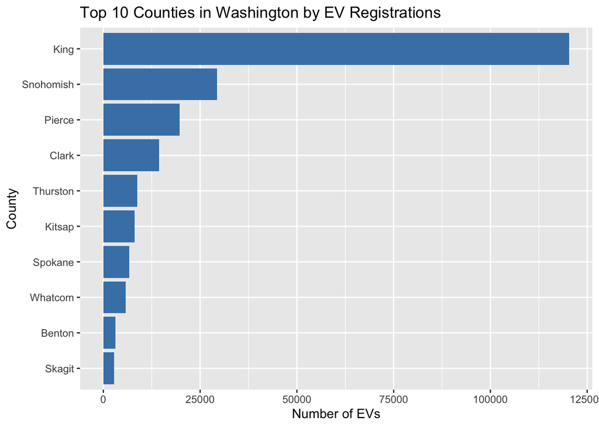

```r
library(ggplot2)

# group by county and count
top_counties <- ev_data %>%
  group_by(County) %>%
  summarise(EV_Count = n()) %>%
  arrange(desc(EV_Count)) %>%
  slice_max(EV_Count, n = 10)  # Top 10 counties

ggplot(top_counties, aes(x = reorder(County, EV_Count), y = EV_Count)) +
  geom_bar(stat = "identity", fill = "steelblue") +
  coord_flip() +
  labs(title = "Top 10 Counties in Washington by EV Registrations",
       x = "County", y = "Number of EVs")
```

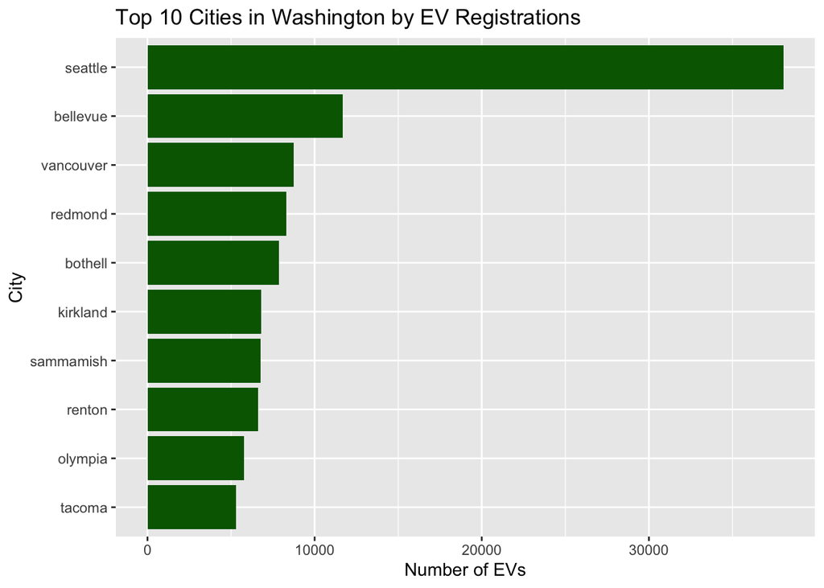

```r
# group by city and count
top_cities <- ev_data %>%
  group_by(City) %>%
  summarise(EV_Count = n()) %>%
  arrange(desc(EV_Count)) %>%
  slice_max(EV_Count, n = 10)  # Top 10 cities

ggplot(top_cities, aes(x = reorder(City, EV_Count), y = EV_Count)) +
  geom_bar(stat = "identity", fill = "darkgreen") +
  coord_flip() +
  labs(title = "Top 10 Cities in Washington by EV Registrations",
       x = "City", y = "Number of EVs")
```

Based on these plots, Seattle and King county have the largest number of electric vehicles. Seattle is in King county so these plots match the data.

## 1. a) When and where are EVs most popular?

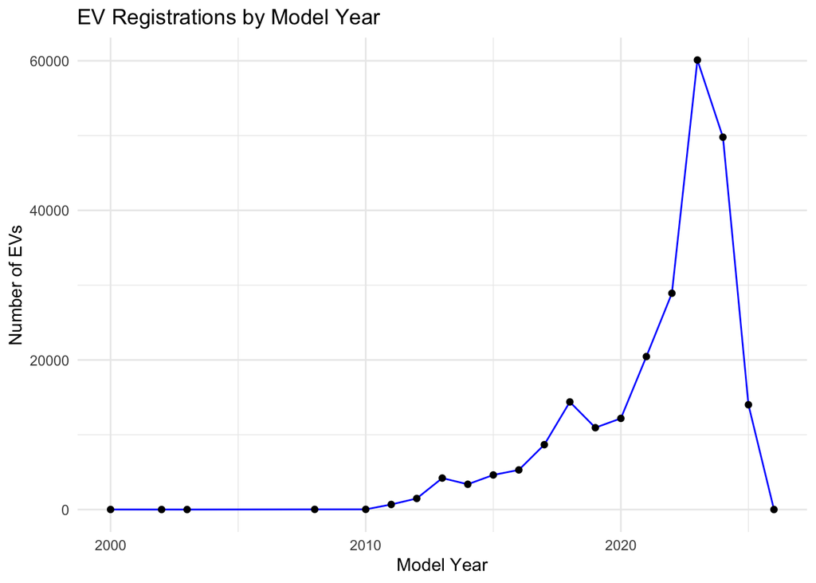

```r
library(dplyr)
library(ggplot2)

# group by model year
ev_trend <- ev_data %>%
  group_by(`Model Year`) %>%
  summarise(EV_Count = n())

ggplot(ev_trend, aes(x = `Model Year`, y = EV_Count)) +
  geom_line(color = "blue") +
  geom_point() +
  labs(title = "EV Registrations by Model Year",
       x = "Model Year", y = "Number of EVs") +
  theme_minimal()
```

```r
# group by model year and county
ev_year_location <- ev_data %>%
  group_by(`Model Year`, County) %>%
  summarise(EV_Count = n())
```

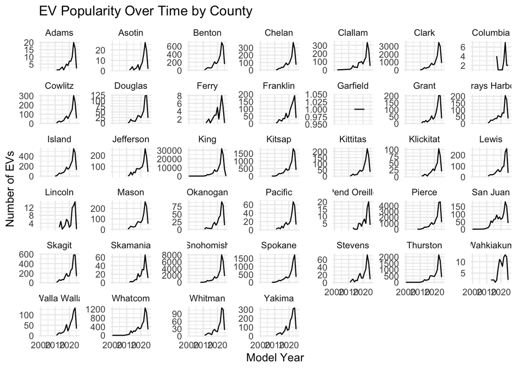

```r
# use facet to compare counties over time
ggplot(ev_year_location, aes(x = `Model Year`, y = EV_Count)) +
  geom_line() +
  facet_wrap(~ County, scales = "free_y") +
  labs(title = "EV Popularity Over Time by County",
       x = "Model Year", y = "Number of EVs") +
  theme_minimal()
```

```r
ev_peak <- ev_data %>%
  group_by(County, `Model Year`) %>%
  summarise(EV_Count = n()) %>%
  arrange(desc(EV_Count)) %>%
  slice(1)
print(ev_peak)
```

```
## # A tibble: 39 × 3
## # Groups:   County [39]
##    County   `Model Year` EV_Count
##    <chr>           <dbl>    <int>
##  1 Adams            2023       20
##  2 Asotin           2023       27
##  3 Benton           2023      691
##  4 Chelan           2023      370
##  5 Clallam          2023      334
##  6 Clark            2023     3464
##  7 Columbia         2023        7
##  8 Cowlitz          2023      301
##  9 Douglas          2024      123
## 10 Ferry            2023        8
## # ℹ 29 more rows
```

It looks like that the peak EV registrations was in 2023, which steeply trended down in 2025. This could possibly be because prices went up significantly, or many people already had electric vehicles and the demand lowered.

## 1. b) Are rural or urban areas more likely to adopt EVs?

```r
unique(ev_data$County) # figure out which counties are rural and which ones are urban from this site: https://doh.wa.gov/sites/default/files/legacy/Documents/Pubs/609003.pdf
```

```
##  [1] "Yakima"       "Kitsap"       "King"         "Thurston"     "Snohomish"
##  [6] "Island"       "Skagit"       "Spokane"      "Chelan"       "Walla Walla"
## [11] "Adams"        "Whitman"      "Stevens"      "Kittitas"     "Douglas"
## [16] "Grant"        "Clark"        "Cowlitz"      "Jefferson"    "Klickitat"
## [21] "Clallam"      "Okanogan"     "Lewis"        "Mason"        "San Juan"
## [26] "Pierce"       "Whatcom"      "Benton"       "Grays Harbor" "Franklin"
## [31] "Wahkiakum"    "Skamania"     "Pacific"      "Pend Oreille" "Asotin"
## [36] "Lincoln"      "Columbia"     "Ferry"        "Garfield"
```

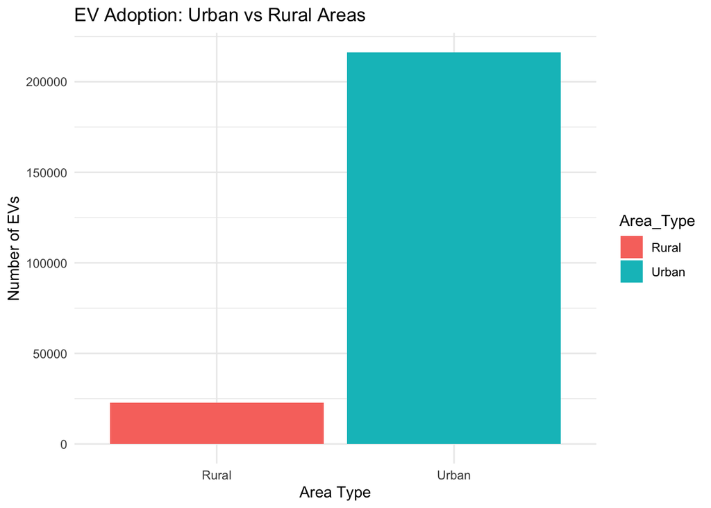

```r
urban_counties <- c("Whatcom", "Snohomish", "Kitsap", "King", "Pierce", "Thurston", "Clark", "Benton", "Spokane")

# new column: Urban vs Rural
ev_data <- ev_data %>%
  mutate(Area_Type = ifelse(County %in% urban_counties, "Urban", "Rural"))

# Count EVs by area type
area_summary <- ev_data %>%
  group_by(Area_Type) %>%
  summarise(EV_Count = n())

ggplot(area_summary, aes(x = Area_Type, y = EV_Count, fill = Area_Type)) +
  geom_bar(stat = "identity") +
  labs(title = "EV Adoption: Urban vs Rural Areas",
       x = "Area Type", y = "Number of EVs") +
  theme_minimal()
```

From this result, it is clear that electric vehicles are more wide spread in urban counties. This makes sense because urban areas can be more environmentally friendly. Urban areas, especially cities, value efficiency in resources is some cases. So, it makes sense more people within cities would have electric vehicles, there also is probably more access to charging stations in urban areas.

## 2. What types of electric vehicles are being adopted?

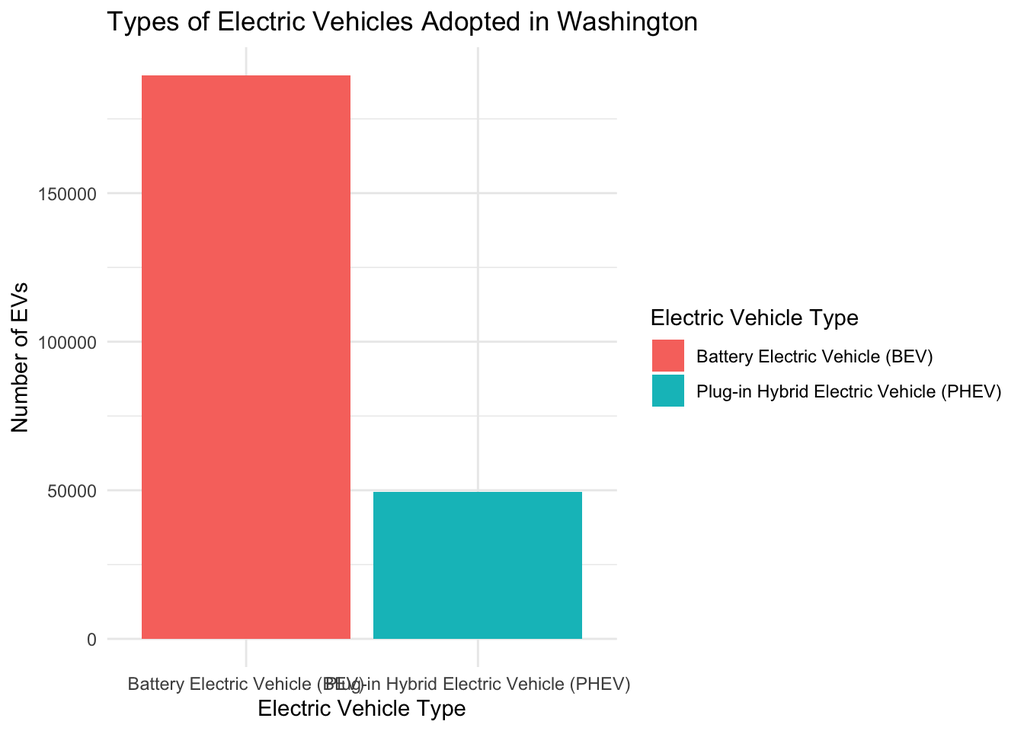

```r
library(dplyr)
library(ggplot2)

# count of each EV type
ev_type_summary <- ev_data %>%
  group_by(`Electric Vehicle Type`) %>%
  summarise(EV_Count = n())

ggplot(ev_type_summary, aes(x = reorder(`Electric Vehicle Type`, -EV_Count), y = EV_Count, fill = `Electric Vehicle Type`)) +
  geom_bar(stat = "identity") +
  labs(title = "Types of Electric Vehicles Adopted in Washington",
       x = "Electric Vehicle Type", y = "Number of EVs") +
  theme_minimal()
```

Clearly, battery electric vehicles are more common in WA compared to plug-in hybrid electric vehicles. This is better for the environment since hybrid cars combine a gasoline engine with an electric battery. So, more battery electric vehicles reduces the carbon footprint more.

## 2. a) What is the distribution of BEVs vs. PHEVs by county or city?

```r
# count EV types by County
ev_by_type_and_county <- ev_data %>%
  group_by(County, `Electric Vehicle Type`) %>%
  summarise(EV_Count = n())
```

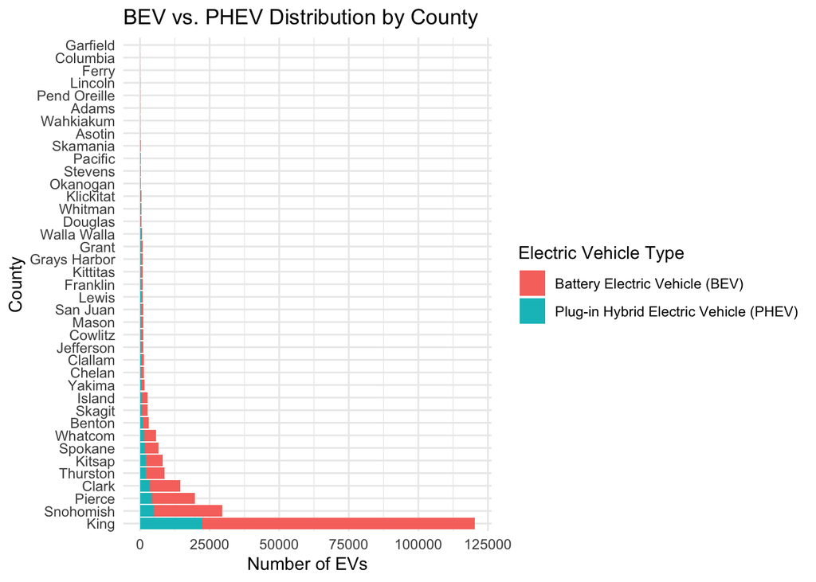

```r
ggplot(ev_by_type_and_county, aes(x = reorder(County, -EV_Count), y = EV_Count, fill = `Electric Vehicle Type`)) +
  geom_bar(stat = "identity") +
  labs(title = "BEV vs. PHEV Distribution by County",
       x = "County", y = "Number of EVs") +
  theme_minimal() +
  coord_flip()
```

This distribution is reflecting how the urban counties have a higher number of battery only electric vehicles compared to hybrid vehicles. For each county, the ratios are very similar when comparing the counts.

## 3. How do economic or policy factors relate to EV adoption?

Here, I am using data on retail gas prices in Washington every month.

```r
library(readr)
library(dplyr)
library(tidyr)

Gas_Prices <- read_csv("~/Documents/Washington_All_Grades_All_Formulations_Retail_Gasoline_Prices.csv", skip = 4)
head(Gas_Prices)
```

```
## # A tibble: 6 × 2
##   Month    Washington All Grades All Formulations Retail Gasoline Prices Dolla…¹
##   <chr>                                                                    <dbl>
## 1 Apr 2025                                                                  4.26
## 2 Mar 2025                                                                  4.06
## 3 Feb 2025                                                                  4.04
## 4 Jan 2025                                                                  3.88
## 5 Dec 2024                                                                  3.89
## 6 Nov 2024                                                                  3.95
## # ℹ abbreviated name:
## #   ¹`Washington All Grades All Formulations Retail Gasoline Prices Dollars per Gallon`
```

```r
#str(Gas_Prices)
#View(Gas_Prices)
#colnames(Gas_Prices)
```

```r
library(lubridate)
```

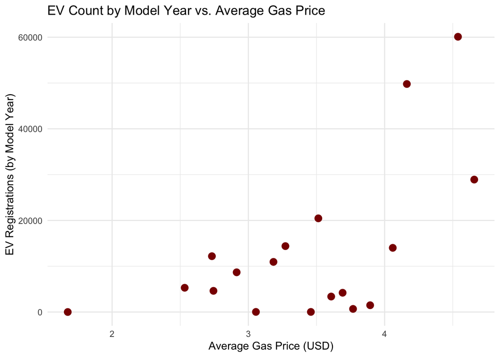

```r
library(ggplot2)

gas_yearly <- Gas_Prices %>%
  rename(Month = `Month`, Price = `Washington All Grades All Formulations Retail Gasoline Prices Dollars per Gallon`) %>%
  mutate(
    Date = parse_date_time(Month, orders = "b Y"),
    Year = year(Date),
    Price = as.numeric(Price)
  ) %>%
  group_by(Year) %>%
  summarise(Avg_Gas_Price = mean(Price, na.rm = TRUE))

ev_yearly <- ev_data %>%
  group_by(`Model Year`) %>%
  summarise(EV_Count = n()) %>%
  rename(Year = `Model Year`)

ev_gas_combined <- left_join(ev_yearly, gas_yearly, by = "Year")

ggplot(ev_gas_combined, aes(x = Avg_Gas_Price, y = EV_Count)) +
  geom_point(color = "darkred", size = 3) +
  labs(title = "EV Count by Model Year vs. Average Gas Price",
       x = "Average Gas Price (USD)",
       y = "EV Registrations (by Model Year)") +
  theme_minimal()
```

```r
cor.test(ev_gas_combined$Avg_Gas_Price, ev_gas_combined$EV_Count)
```

```
##
##  Pearson's product-moment correlation
##
## data:  ev_gas_combined$Avg_Gas_Price and ev_gas_combined$EV_Count
## t = 2.9748, df = 16, p-value = 0.008937
## alternative hypothesis: true correlation is not equal to 0
## 95 percent confidence interval:
##  0.1800560 0.8318651
## sample estimates:
##       cor
## 0.5967607
```

```r
#testing correlation between the two
```

This result is very interesting because when gas prices were below $3, EV registration counts did not increase nor decrease. Once gas prices began to increase and stay between 3-4 dollars, Ev registrations slightly increased. Finally, when gas prices exceeded 4 dollars, EV registrations in Washington increased significantly.

```r
ev_type_year <- ev_data %>%
  group_by(`Model Year`, `Electric Vehicle Type`) %>%
  summarise(EV_Count = n()) %>%
  rename(Year = `Model Year`)
```

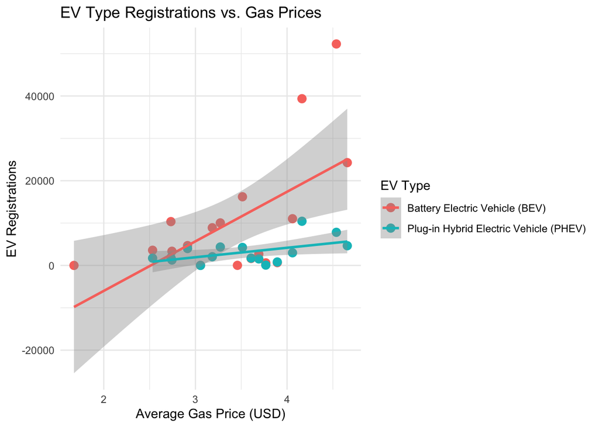

```r
ev_type_gas <- left_join(ev_type_year, gas_yearly, by = "Year")


library(ggplot2)

ggplot(ev_type_gas, aes(x = Avg_Gas_Price, y = EV_Count, color = `Electric Vehicle Type`)) +
  geom_point(size = 3) +
  geom_smooth(method = "lm", se = TRUE) +
  labs(title = "EV Type Registrations vs. Gas Prices",
       x = "Average Gas Price (USD)",
       y = "EV Registrations",
       color = "EV Type") +
  theme_minimal()
```

Looking at this plot, the linear patterns show that EV registrations increased more in battery electric vehicles compared to plug-in hybrid electric vehicles.

```r
correlations <- ev_type_gas %>%
  group_by(`Electric Vehicle Type`) %>%
  summarise(Correlation = cor(Avg_Gas_Price, EV_Count, use = "complete.obs"))

print(correlations)
```

```
## # A tibble: 2 × 2
##   `Electric Vehicle Type`                Correlation
##   <chr>                                        <dbl>
## 1 Battery Electric Vehicle (BEV)               0.599
## 2 Plug-in Hybrid Electric Vehicle (PHEV)       0.513
```

These correlations are both positive and moderate, with BEV’s having a bit stronger correlation compared to PHEV’s.

## 4. How does average AQI in Clallam and King county compare to the number of EV registrations?

```r
library(readr)
ad_viz_plotval_data <- read_csv("~/Documents/ad_viz_plotval_data.csv")
#View(ad_viz_plotval_data)



library(readr)
library(dplyr)

ad_viz_plotval_data <- read_csv("~/Documents/ad_viz_plotval_data.csv")
# average AQI for each county
avg_aqi_by_county <- ad_viz_plotval_data %>%
  group_by(County) %>%
  summarise(avg_AQI = mean(`Daily AQI Value`, na.rm = TRUE))

head(avg_aqi_by_county)
```

```
## # A tibble: 2 × 2
##   County  avg_AQI
##   <chr>     <dbl>
## 1 Clallam    1.06
## 2 King       3.95
```

```r
library(dplyr)

ev_by_county <- ev_data %>%
  filter(County %in% c("Clallam", "King")) %>%  # Only include these two counties
  group_by(County) %>%
  summarise(EV_Count = n())

# combine EV counts with average AQI
combined_data <- ev_by_county %>%
  left_join(avg_aqi_by_county, by = "County")

print(combined_data)
```

```
## # A tibble: 2 × 3
##   County  EV_Count avg_AQI
##   <chr>      <int>   <dbl>
## 1 Clallam     1439    1.06
## 2 King      120354    3.95
```

Here, it is clear that King county has an average daily AQI about 4 times as much as Clallam county.

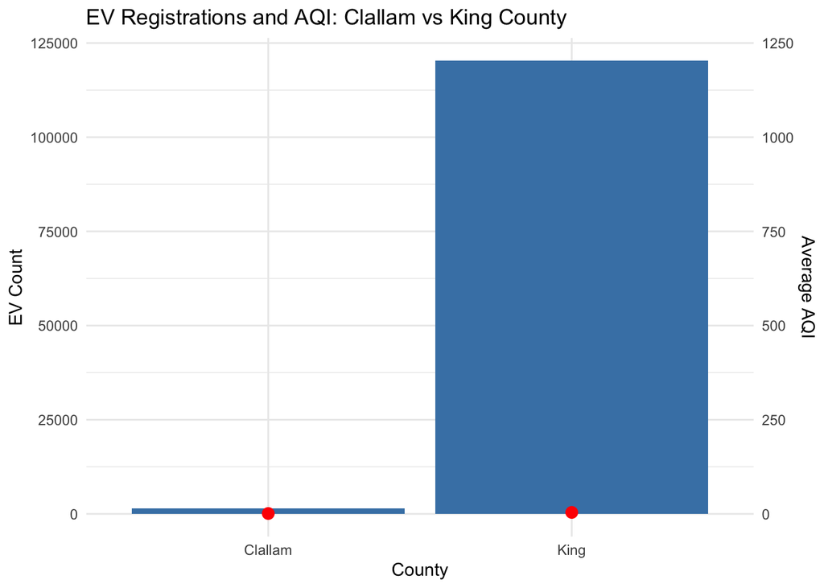

```r
library(ggplot2)

ggplot(combined_data, aes(x = County)) +
  geom_bar(aes(y = EV_Count), stat = "identity", fill = "steelblue") +
  geom_point(aes(y = avg_AQI * 100), color = "red", size = 3) +  # scaled AQI for visibility
  scale_y_continuous(
    name = "EV Count",
    sec.axis = sec_axis(~./100, name = "Average AQI")  # scale AQI back for axis
  ) +
  labs(title = "EV Registrations and AQI: Clallam vs King County") +
  theme_minimal()
```

From doing further research, the population in King county is roughly around 755,000 while the population in Clallam county is roughly around 77,000. Since Clallam county is 1/10 the size of King county, it makes sense that King county would have a higher average daily AQI because a higher population contributes to a a higher carbon footprint. So, having more electric vehicles in a place with a higher AQI shows that people are aware of the environment’s conditions and are trying to help.

## 5. Which EV make is most popular in Washington?

```r
library(dplyr)

brand_popularity <- ev_data %>%
  group_by(Make) %>%
  summarise(Count = n()) %>%
  arrange(desc(Count))

print(brand_popularity)
```

```
## # A tibble: 46 × 2
##    Make       Count
##    <chr>      <int>
##  1 TESLA     101423
##  2 CHEVROLET  17438
##  3 NISSAN     15594
##  4 FORD       12819
##  5 KIA        11737
##  6 BMW         9850
##  7 TOYOTA      9752
##  8 HYUNDAI     7624
##  9 RIVIAN      6983
## 10 JEEP        6168
## # ℹ 36 more rows
```

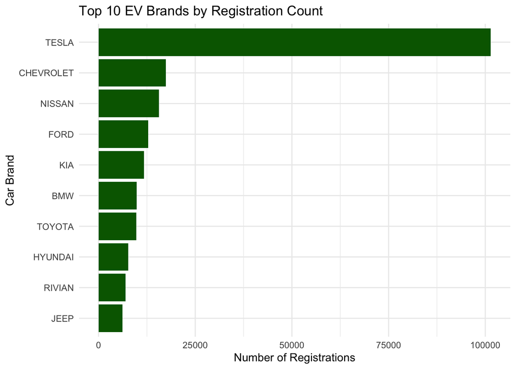

```r
library(ggplot2)

top_brands <- brand_popularity %>%
  slice_max(Count, n = 10)

ggplot(top_brands, aes(x = reorder(Make, Count), y = Count)) +
  geom_col(fill = "darkgreen") +
  coord_flip() +
  labs(title = "Top 10 EV Brands by Registration Count",
       x = "Car Brand",
       y = "Number of Registrations") +
  theme_minimal()
```

I found this question interesting because Teslas have been very popular the last few years and more and more people are buying them. I can assume that the marketing and push for the Tesla electric car definitely had a huge influence on the amount EV registration’s in Washington.

## Sources

Where I got the data from: https://catalog.data.gov/dataset/electric-vehicle-population-data https://www.eia.gov/dnav/pet/hist/LeafHandler.ashx?n=PET&s=EMM_EPM0_PTE_SWA_DPG&f=M https://www.epa.gov/outdoor-air-quality-data/download-daily-data